# DA 5030 Final Project: Lung Cancer Prediction through Machine learning Algorithms

Dr. Nishat Fatima Mohammad

04/03/2024

## Business Understanding.

Lung cancer is the 2nd most common cancer worldwide and in women and the most common cancer in men according to the World Cancer Research Fund International4, with smoking being the most common predisposing factor. Cases have emerged with no decisive hint at the etiology, so we turn to the genetic causes. The interplay of predisposing factors and genes has uplifted the need for personalized medicine and the heterogeneity of cancer is nice and random to apply Machine Learning Algorithms to personalize treatment modalities. Genetic classification of cancers is rapidly becoming the norm and early detection is evermore paramount to screen the patients and their close relatives.

## Aim of the Ananlysis.

To leverage appropriate Machine learning algorithms and data mining methods to overcome the complexities of Squamous Cell Lung Cancer RNA-Seq data to predict tumor cases.

## Data Source.

The dataset is called TCGA–LUSC (Lung Squamous Cell Carcinoma) Expression Profiling by Array (Microarray) Data set, obtained from Kaggle. It comprises of RNA Seq data from 49 normal cases and 502 squamous cell lung cancer cases. I accessed thecsv.zip file will be working on it in the data exploration section.

## Load Packages.

These packages will be required for this analysis. Others will be loaded on the go as required in various code chunks.

```r
library(data.table)
library(dplyr)
library(tidyr)
library(tibble)
library(gplots)
library(ggplot2)
library(stats)
library(purrr)
library(caret)
library(e1071)
library(randomForest)
```

## 1. Data Exploration:

I will examine the data on a highly level after loading it and wrok forwards thereafter.

### 1.1. Load and look at the data on a high level

```r
# file name
#file <- "LUSCexpfile.csv.zip"
#unzip(file)
unzipd_file <- "LUSCexpfile.csv"

# Load using read.csv
lusc_data <- fread(unzipd_file, sep = ";")

# Explore the data
#glimpse(lusc_data)
#str(lusc_data)
#head(lusc_data)
dim(lusc_data)
```

```
## [1] 56909   552
```

Here the structure of the data has been looked at after loading the data using `fread()`. This function is faster than `read.csv()` and thus the choice here since we have a 231.2 MB data file. The `glimpse()` function also gives us a look at the data and the first few rows of the data are looked at using `head()`. It is observed that the columns do not have names. also the genes should be the columns and the patient ids should be the rows. The dimensions are shown above.

### 1.2. Transpose data.

The dimensions will be switched here.

```r
# Transpose the data frame
lusc_data_t<- as.data.frame(t(lusc_data))

# Gene names to columns
colnames(lusc_data_t) <- lusc_data_t[1, ]
lusc_data_t <- lusc_data_t[-1, ]
#str(lusc_data_t)
#head(lusc_data_t)
dim(lusc_data_t)
```

```
## [1]   551 56909
```

The tranposed dat now has gene names as the column names with that row deleted. I have commented head and str functions to avoid overwhelming the document with long tables.

### 1.3. Fix the row and column names and orientation.

Here, I will try to rename the columns and then switch the rows to columns so we can have the observations in the rows and the variables (genes) in the columns.

```r
# Change row names to id
rownames(lusc_data_t) <- NULL
#head(lusc_data_t)

# Name the first column  outcome
colnames(lusc_data_t)[1] <- "patient_id"
#head(lusc_data_t)
colnames(lusc_data_t)[2] <- "outcome"
outcomes <- unique(lusc_data_t$outcome)

# Take off the pateint id for now
lusc_data_t2 <- lusc_data_t[,2:ncol(lusc_data_t)]
#head(lusc_data_t2)
```

The column with the normal and tumor classes is called outcome and the ID column is called patient_id and taken off.

### 1.4. Missing values.

The missing values in this data will be NA, zeros.

```r
sum(is.na(lusc_data_t2))
```

```
## [1] 0
```

```r
# Get the number of transcripts with zero expression
num_zero_genes <- sum(apply(lusc_data_t2, 2, function(row) sum(row == 0)))
num_rows_with_zeros <- sum(apply(lusc_data_t2, 1, function(row) any(row == 0)))
dim(lusc_data_t2)
```

```
## [1]   551 56908
```

Here there are no missing values in the data. There are zero expression values for variables in every row of the of the data. Recall these variables are trancripts and the values of zero may indicate that the transcript is not expressed in that that observation. I will take off columns with all zero values.

#### 1.4.1. Handle zero values as Missing values.

It is impossible to have genes with equal expression all through our samples, thus columns with all zero values and all constant values will be considered as Missing values and will be taken off.

```r
# Constant columns
constant_cols <- apply(lusc_data_t2, 2, function(x) length(unique(x)) == 1)
# Remove constant columns
lusc_data_t2 <- lusc_data_t2[, !constant_cols]
dim(lusc_data_t2)
```

```
## [1]   551 55261
```

The data now has 55,261 columns instead of 56909 columns.

### 1.5. Visualize data trends.

Let us take a look at the data in general through visualizations.

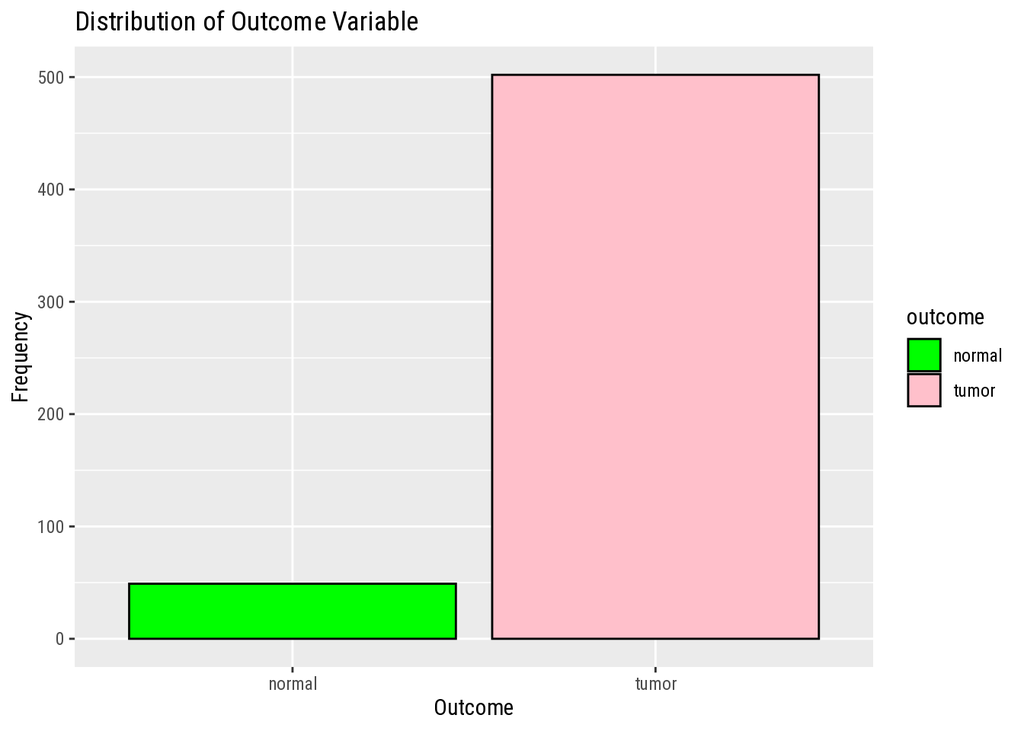

```r
#Get distribution of outcome
outcome_prop <- table(lusc_data_t2$outcome) / length(lusc_data_t2$outcome)
#outcome_prop

# Visualize outcome classes
ggplot(lusc_data_t2, aes(x = outcome, fill = outcome)) +
  geom_bar(color = "black") +
  labs(title = "Distribution of Outcome Variable", x = "Outcome", y = "Frequency") +
  scale_fill_manual(values = c("normal" = "green", "tumor" = "pink"))
```

### 1.6. Encode Features.

```r
# Binary encode the outcome with positive class being tumor
lusc_data_t2$outcome<-as.factor(ifelse(lusc_data_t2$outcome == "tumor", 1, 0))
#head(lusc_data_t2)
#tail(lusc_data_t2)
```

Here the outcome variable is binary encoded 1 for tumor and 0 for normal.

### 1.7. Feature transformation.

```r
# Transform all character values to numeric
lusc_data_t2 <- mutate_all(lusc_data_t2, function(x) as.numeric(as.character(x)))
#str(lusc_data_t2)
#head(lusc_data_t2)
any(is.na(lusc_data_t2))
```

```
## [1] FALSE
```

All variables are changed to numeric for further analysis, this will be adjusted as per requirements of the models that will be used.

### 1.8. Visualize with PCA.

[figure not shown]

```r
set.seed(786)
# Perform PCA
pca_result <- prcomp(lusc_data_t2, scale. = TRUE)
#summary(pca_result)
biplot(pca_result)
```

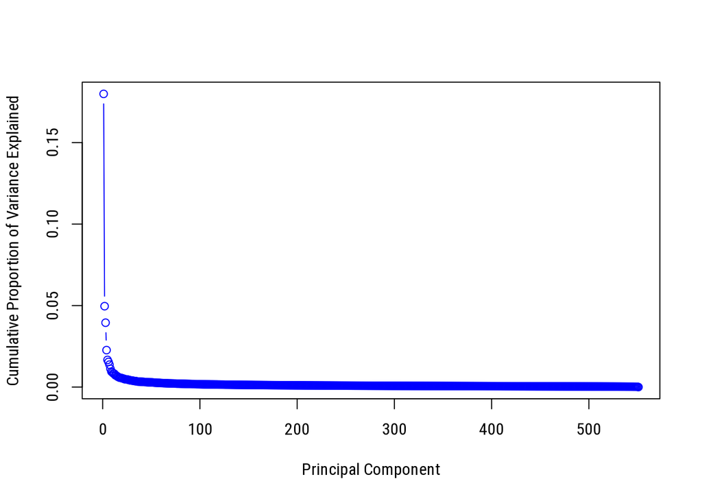

```r
# Get eigen values
eg_vals <- pca_result$sdev^2
# Get variance explained by each principal component
variance_exp<- eg_vals / sum(eg_vals)
# Visualize
plot(1:length(eg_vals), variance_exp, type = "b", col = "blue",
     xlab = "Principal Component", ylab = "Cumulative Proportion of Variance Explained")
```

Here the target variable is the outcome variable in the first column and its distribution can be seen above. The proportionality between the normal and tumor cases is seen in the tumor and visualized with a bar plot. The data is imbalalnced and can pose a problem when training models, in that it will cause the model to be biased towards the highly represented data in this case the tumor cases. I look at the PCA for an overall look at the data clusters with a scree plot showing the first 6-10 components should be considered for this.

### 1.9. Data Balancing.

Here I will demonstrate data balancing on a subset of the data by random oversampling. I have tried to use SMOTE, ROSE without good results and thus relying on rwo() function form the imbalance package. It is arguable that I am balancing the data before splitting which could cause overfitting, but I will do hyperparametric model tuning and k-fold cross validation to reduce the overfitting that may have been introduced. It is subjective to choose the chronology of steps between balancing, dimensionality reduction and splitting the data. while I must reduce dimensions of my data using PCA before splitting, I must also decide when to do balancing, both cannot be done after splitting, so I choose to balance and reduce dimensionality before splitting and then manage my models to reduce overfitting based on the given time I have to carry out this analysis.

```r
set.seed(786)
sub_lusc_dt_normal <- lusc_data_t2[1:10,]
sub_lusc_dt_tumor <- lusc_data_t2[50:70,]
sub_lusc_dt <- data.frame(rbind(sub_lusc_dt_normal, sub_lusc_dt_tumor))
dim(sub_lusc_dt)
```

```
## [1]    31 55261
```

```r
sub_outcomes <- sub_lusc_dt[, 1]
sub_features <- sub_lusc_dt[, -1]

library(imbalance)
extra_normal_outcomes <- rwo(sub_lusc_dt, numInstances =20 , classAttr = "outcome")
dim(extra_normal_outcomes)
```

```
## [1]    20 55261
```

```r
balanced_sub_lusc_dt <- rbind(extra_normal_outcomes, sub_lusc_dt)
#dim(balanced_sub_lusc_dt)
any(is.na(balanced_sub_lusc_dt))
```

```
## [1] FALSE
```

```r
zero_cols <- colSums(balanced_sub_lusc_dt == 0) == nrow(balanced_sub_lusc_dt)
#Remove all unexpressed genes (columns with all zero values)
cln_sub_dt <- balanced_sub_lusc_dt[, colSums(balanced_sub_lusc_dt != 0) > 0]
dim(balanced_sub_lusc_dt)
```

```
## [1]    51 55261
```

```r
dim(cln_sub_dt)
```

```
## [1]    51 50020
```

Here, I balanced the data based on the outcome variable to get close to equal number of normal and tumor cases in the subset from the main data as a demo. Now I will try to balance the whole data.

#### 1.9.1. Balance the whole data.

```r
# Get outcome and features
all_outcomes <- lusc_data_t2[, 1]
all_features <- lusc_data_t2[, -1]

#Get the new normal data cases
nw_extra_normal_outcomes <- rwo(lusc_data_t2, numInstances = 500, classAttr = "outcome")
dim(nw_extra_normal_outcomes)
```

```
## [1]   500 55261
```

```r
#head(nw_extra_normal_outcomes)
dim(lusc_data_t2)
```

```
## [1]   551 55261
```

```r
nw_vars <- intersect(colnames(nw_extra_normal_outcomes), colnames(lusc_data_t2))
complete_balanced_dt <- lusc_data_t2[,nw_vars]
#head(complete_balanced_dt)
nw_extra_normal_outcomes <- nw_extra_normal_outcomes[,nw_vars]
complete_balanced_dt <- rbind(nw_extra_normal_outcomes, complete_balanced_dt)
#head(complete_balanced_dt)


dim(complete_balanced_dt)
```

```
## [1]  1051 51166
```

```r
any(is.na(complete_balanced_dt))
```

```
## [1] FALSE
```

```r
zero_cols <- colSums(complete_balanced_dt == 0) == nrow(complete_balanced_dt)
#Remove all un expressed genes (columns with all zero values)
cln_balanced_dt <- complete_balanced_dt[, colSums(complete_balanced_dt != 0) > 0]
dim(complete_balanced_dt)
```

```
## [1]  1051 51166
```

```r
dim(cln_balanced_dt)
```

```
## [1]  1051 51166
```

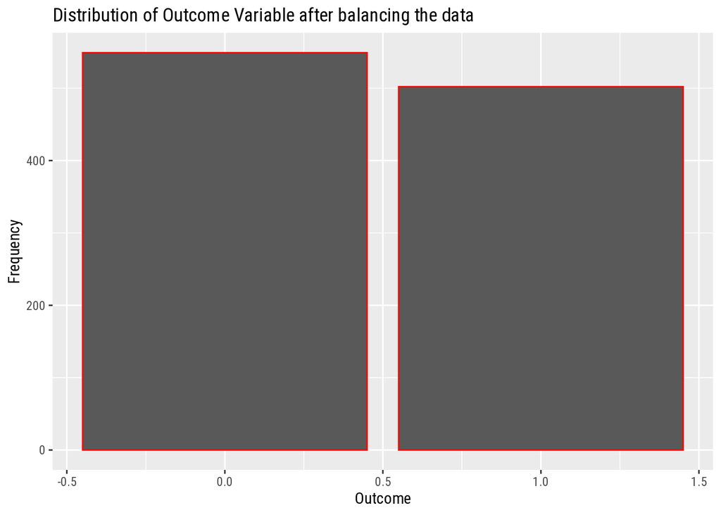

```r
#Visualize outcome classes in balanced data
ggplot(cln_balanced_dt, aes(x = outcome, fill = outcome)) +
  geom_bar(color = "red") +
  labs(title = "Distribution of Outcome Variable after balancing the data", x = "Outcome", y = "Frequency")
```

Here I successfully balanced the data by random oversampling. Notice there were a few mistaching columns in the over sampled data and the main data, so I focused on the matching variables and also looked out for variables with all zero values but none were found in the cleaning process evidenced by the same dimensions before and after cleaning. I will be cautious of over fitting on the normal outcome types that may occur due to the use of random oversampling technique. The classes in outcome variable can be seen in the bar plot above.

## 2. Dimentionality Reduction.

Considering that I have over 55K features, I have decided to use PCA to carry out dimensionality reduction and will pick the best Principal components for modeling. I have run PCA earlier, and will discuss briefly on how the data clean up has affected the PCA.

### 2.1 Principal Component Analysis.

```r
set.seed(786)
# Perform PCA
pca_result2 <- prcomp(cln_balanced_dt[, -1], scale. = TRUE)
#pca_result2$sdev
length(pca_result2$sdev)
```

```
## [1] 1051
```

```r
#pca_result2$rotation
dim(pca_result2$rotation)
```

```
## [1] 51165  1051
```

```r
#pca_result2$x
dim(pca_result2$x)
```

```
## [1] 1051 1051
```

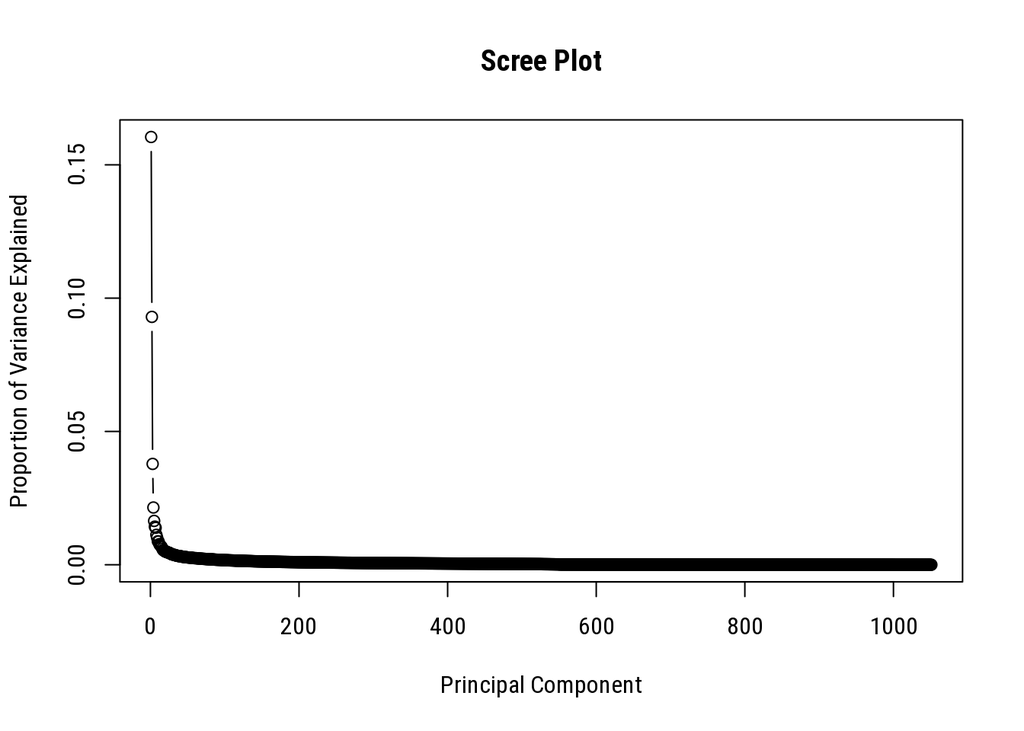

```r
# Scree plot
scree_data <- pca_result2$sdev^2
scree_proportion <- scree_data / sum(scree_data)
plot(1:length(scree_proportion), scree_proportion, type = "b",
     xlab = "Principal Component", ylab = "Proportion of Variance Explained",
     main = "Scree Plot")
```

### 2.2. Apply PCA for Dimensionality reduction.

```r
#Number of PC to use
top_pc <- 30
pca_features <- pca_result2$x[, 1:top_pc]
dim(pca_features)
```

```
## [1] 1051   30
```

```r
#str(pca_features)
# Get a data frame
pca_features_df <- as.data.frame(pca_features)
colnames(pca_features_df) <- paste0("PC", 1:30)

# Combine with outcome variable
pca_dt <- cbind(cln_balanced_dt$outcome, pca_features_df)
colnames(pca_dt)[1] <- "outcome"
dim(pca_dt)
```

```
## [1] 1051   31
```

```r
str(pca_dt)
```

```
## 'data.frame':    1051 obs. of  31 variables:
##  $ outcome: num  0 0 0 0 0 0 0 0 0 0 ...
##  $ PC1    : num  -24.95 -30.52 -20.24 -9.54 3.86 ...
##  $ PC2    : num  -70.6 -55.2 -61.4 -50.9 -52.1 ...
##  $ PC3    : num  -10.3 -51.8 10.9 14.7 67.8 ...
##  $ PC4    : num  26.05 18.59 2.38 -29.69 -24.19 ...
##  $ PC5    : num  -13.039 0.116 -18.801 39.211 -21.144 ...
##  $ PC6    : num  -0.382 4.523 6.612 4.484 -30.339 ...
##  $ PC7    : num  8.711 -0.381 -26.262 -23.341 -5.452 ...
##  $ PC8    : num  -7.15 -5.5 1.55 13.79 -13.42 ...
##  $ PC9    : num  13.3 15.7 19.9 21.1 -25.1 ...
##  $ PC10   : num  -1.172 2.162 15.78 -0.288 -2.918 ...
##  $ PC11   : num  1.51 -1.64 -26.09 -4.48 -32.45 ...
##  $ PC12   : num  -7.084 -7.672 -7.022 4.288 0.051 ...
##  $ PC13   : num  7.69 12.09 -20.75 -6.28 -3.84 ...
```

[output cut: 17 more lines]

```r
#head(pca_dt)
#tail(pca_dt)
```

The data now has 30 top principal components as the features in the columns and this will be worked with to split the data. the new data can be seen above.

### 2.3. Determine correlation between principal components.

I have decided to carry out the correlation analysis after the dimensionality reduction considering the number of variables in the original data set were 55000+ that would generate a huge correlation matrix and I expect lots of colinearity as well. itis better then to focus on the mostimportant features after dimentionslity reduction and view the correlation at this point.

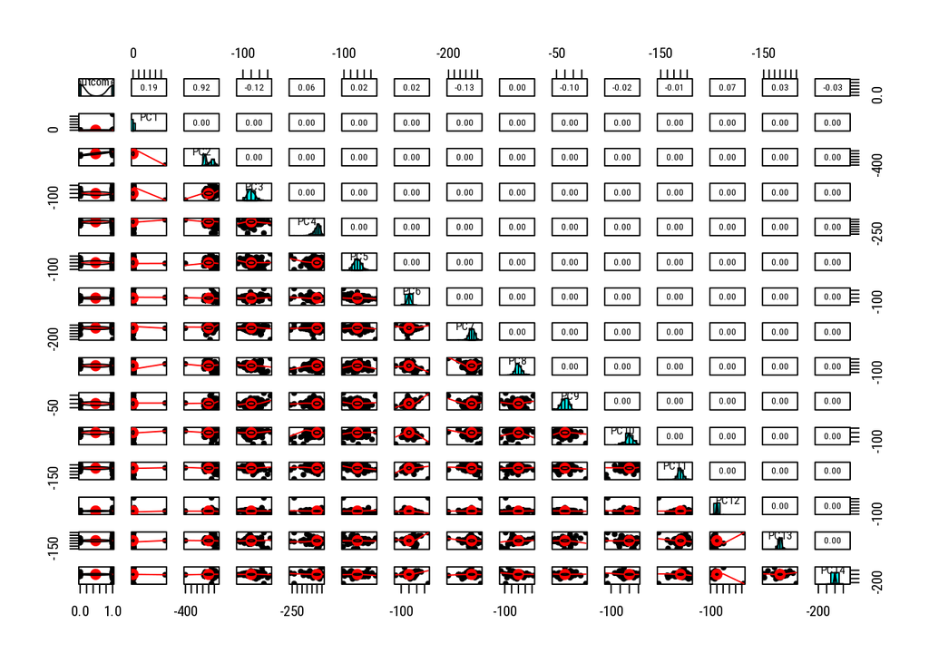

```r
set.seed(786)
library(psych)
pairs.panels(pca_dt[,1:15])
```

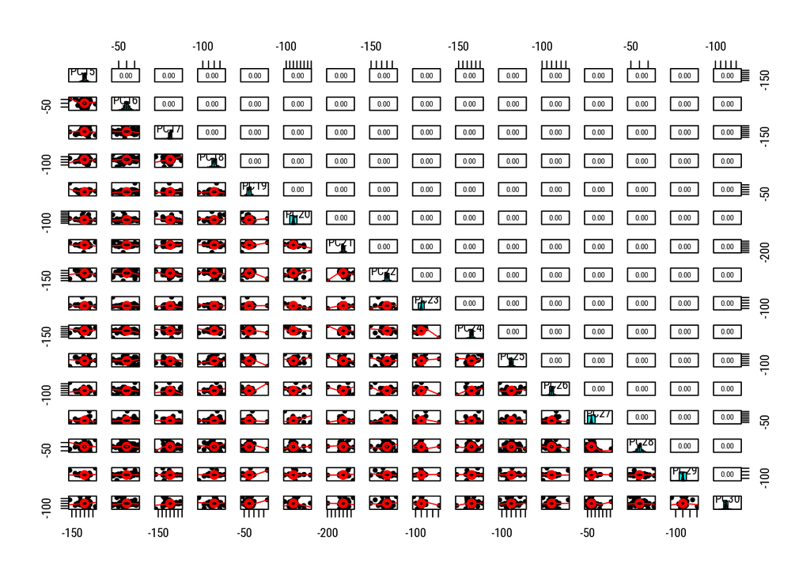

```r
pairs.panels(pca_dt[,16:31])
```

```r
# Spearman correlation between the outcome and PC
cor(pca_dt$outcome,pca_dt[, -1], method = "spearman")
```

```
##            PC1       PC2        PC3       PC4        PC5          PC6
## [1,] 0.7338275 0.8602246 -0.1580528 0.1345653 0.03128535 -0.007866855
##             PC7        PC8        PC9        PC10       PC11      PC12
## [1,] -0.1554473 0.06289089 -0.1556545 -0.01465382 0.03523447 0.1516614
##            PC13        PC14       PC15       PC16       PC17       PC18
## [1,] 0.02186772 0.000408097 0.02713531 0.09705803 0.03171856 0.06490626
##            PC19       PC20       PC21       PC22        PC23        PC24
## [1,] 0.01013964 0.07084564 0.05764214 0.01699567 -0.04867028 -0.04183936
##            PC25       PC26        PC27       PC28       PC29       PC30
## [1,] 0.07028059 0.01708985 -0.05807535 -0.0554698 -0.1487419 0.04413098
```

```r
# looking for multicolinearity among pc
head(cor(pca_dt, method="spearman"))
```

```
##             outcome         PC1         PC2         PC3         PC4        PC5
## outcome  1.00000000  0.73382751  0.86022458 -0.15805284  0.13456529 0.03128535
## PC1      0.73382751  1.00000000  0.75668276  0.42229079 -0.07759181 0.09700115
## PC2      0.86022458  0.75668276  1.00000000 -0.07079121  0.04056573 0.12157617
## PC3     -0.15805284  0.42229079 -0.07079121  1.00000000 -0.05361420 0.01376860
## PC4      0.13456529 -0.07759181  0.04056573 -0.05361420  1.00000000 0.06873740
## PC5      0.03128535  0.09700115  0.12157617  0.01376860  0.06873740 1.00000000
##                  PC6         PC7         PC8         PC9        PC10
## outcome -0.007866855 -0.15544730  0.06289089 -0.15565448 -0.01465382
## PC1     -0.185460773  0.04432251 -0.05448275 -0.12934597 -0.05452243
## PC2     -0.007666985 -0.07337952  0.08640226  0.02539858  0.03351509
## PC3     -0.094185833  0.19415625 -0.06922414 -0.05476961  0.00400436
## PC4      0.045509241 -0.05474262 -0.10764989  0.06472228 -0.14234417
## PC5      0.080289732  0.06845309 -0.07775933  0.04033060 -0.02470153
##                PC11        PC12         PC13         PC14        PC15
## outcome  0.03523447  0.15166141  0.021867722  0.000408097  0.02713531
## PC1      0.06518188  0.13343972  0.051474093  0.124263486 -0.01707526
## PC2      0.01419268  0.08310728 -0.008367882  0.076370576 -0.03077919
## PC3      0.03324905 -0.03257487  0.043981020  0.046325483  0.05319394
## PC4     -0.05929922  0.13966488  0.048742570 -0.045160859  0.01061260
## PC5     -0.02555049  0.08361382  0.022484967 -0.096561698  0.03205180
##                PC16         PC17         PC18        PC19        PC20
## outcome  0.09705803  0.031718557  0.064906262  0.01013964  0.07084564
## PC1      0.08510854 -0.000300389  0.049756767 -0.01986784  0.03337272
## PC2      0.11921058  0.027505849  0.004942377 -0.17545384 -0.04831373
## PC3      0.04237023 -0.051599951  0.075535914  0.04570742 -0.02481477
## PC4     -0.07126565  0.074788905  0.137850628 -0.05841577  0.10193814
## PC5      0.08323529  0.089584540 -0.039085509 -0.08486399 -0.09423533
##                 PC21        PC22        PC23        PC24        PC25
## outcome  0.057642135  0.01699567 -0.04867028 -0.04183936  0.07028059
## PC1      0.077654648  0.05941618 -0.13244031  0.02243867  0.16428914
## PC2      0.038031042  0.04048222 -0.03340924  0.01266711 -0.01739710
## PC3     -0.049356114  0.07281945  0.10125214 -0.00715846  0.10014752
## PC4      0.056152321 -0.04775619  0.25603031 -0.16674336  0.08669398
## PC5     -0.005892756  0.05611014 -0.09903095  0.02985415 -0.02760267
##                PC26        PC27         PC28        PC29        PC30
## outcome  0.01708985 -0.05807535 -0.055469803 -0.14874195  0.04413098
## PC1     -0.03259736 -0.08547766 -0.020263756 -0.07109451 -0.07733108
## PC2      0.03505668 -0.08209374 -0.047389977 -0.09190049 -0.01334628
## PC3     -0.07971911 -0.01338053 -0.009675863  0.02181861 -0.08092219
## PC4     -0.08774183  0.16371082 -0.041078469 -0.07954298 -0.09159697
## PC5     -0.07891935  0.04060494 -0.075190892 -0.11197428  0.05528605
```

The correlation has been visualized in the pairs panel and the correlation of all principal components to the outcome has been looked at through Spearman method (Spearman correlation is robust to outliers, can capture non-linear relationships, popular for biological data).  
PC3,6, 7,9, 10, 23, 24, 27, 28 and 29 have negative correlation coefficients and the rest ar positively correlated to the outcome.  
PC2 is the most strongly and directly correlated to the outcome followed by PC1.

PC1 and PC2 have a correlation coefficient of about 0.76, showing they capture similar patterns where as PC3 is close to zero showing it captures a separate type of pattern.

## 3. Data Splitting and Data Stratification.

I will split the data into 3 parts; training, validation and test sets using 70:15:15 ratio respectively based on the outcome data.

### 3.1. Training set

```r
set.seed(786)
# Separate the outcome types
outcome1tumor <- pca_dt[pca_dt$outcome == 1, ]
outcome0normal <- pca_dt[pca_dt$outcome == 0, ]
#head(outcome0normal)

# Get nrows for training set
out_neg <- sample(rownames(outcome0normal), 0.70 * nrow(outcome0normal))
out_pos <- sample(rownames(outcome1tumor), 0.70 * nrow(outcome1tumor))

# Get the full training set
training_set <- rbind(pca_dt[out_neg,],pca_dt[out_pos,])
dim(training_set)
```

```
## [1] 735  31
```

```r
#head(training_set)
unique(training_set$outcome)
```

```
## [1] 0 1
```

Here the training set has been created with 70% of each class in the outcome variable. Now I will create the validation and sets from the remaining 30 % of the data.

### 3.2. Validation set.

```r
set.seed(786)
# remaining data
rem_dt <- pca_dt[!(row.names(pca_dt) %in% c(out_neg,out_pos)),]
dim(rem_dt)
```

```
## [1] 316  31
```

```r
# Get the outcome classes
rem_outcome0 <- rem_dt[rem_dt$outcome == 0, ]
rem_outcome1 <- rem_dt[rem_dt$outcome == 1, ]

# Get 50% of each class
rem_out_neg <- sample(rownames(rem_outcome0), 0.50 * nrow(rem_outcome0))
rem_out_pos <- sample(rownames(rem_outcome1), 0.50 * nrow(rem_outcome1))
length(rem_out_pos)
```

```
## [1] 75
```

```r
# Get the validation set
validation_set <- rbind(rem_dt[rem_out_neg,],rem_dt[rem_out_pos,])
dim(validation_set)
```

```
## [1] 157  31
```

Here the validation set is 15% of the entire data set. I will now create the test set form the final remaining 15%.

### 3.3. Testing set.

```r
set.seed(786)
# Get the remaining data for testing set
testing_set <- rem_dt[!(row.names(rem_dt) %in% c(rem_out_neg,rem_out_pos)),]
dim(testing_set)
```

```
## [1] 159  31
```

Now the data has been stratified and split into the various sets. I will scale the split sets now.

## 4. Data transformation and scaling.

This data is already normalized by TPM Transcripts per Million which is more widely accepted that RPKM and FPKM methods of normalization but scaling the data is still necessary. I will scale the training, validation and test sets separately to avoid data leakage. I will utilize min-max scaling and I will be careful not to scale the outcome variable.

```r
# Scale training set
trainin_process <- preProcess(as.data.frame(training_set[,-1]), method=c("range"))
traning_set_scald <- predict(trainin_process, as.data.frame(training_set[,-1]))
traning_set_scald <- cbind(training_set[,1], traning_set_scald)
dim(traning_set_scald)
```

```
## [1] 735  31
```

```r
head(traning_set_scald)
```

```
##     training_set[, 1]          PC1       PC2       PC3       PC4       PC5
## 352                 0 0.0002131775 0.6420325 0.2847716 0.9063602 0.4529907
## 369                 0 0.0023693558 0.6345039 0.3602395 0.9342596 0.5493342
## 343                 0 0.0049400896 0.6197753 0.4707539 0.7007229 0.2258511
## 245                 0 0.0030208044 0.6422855 0.3763829 0.8522242 0.4652908
## 130                 0 0.0094971353 0.6181289 0.5541214 0.7221258 0.4147425
## 94                  0 0.0070657229 0.6285198 0.5028049 0.7486387 0.4644542
##           PC6       PC7       PC8        PC9      PC10      PC11      PC12
## 352 0.4067136 0.6391237 0.3705369 0.54489135 0.3947850 0.3525045 0.3631969
## 369 0.3427262 0.7736265 0.2848805 0.52860008 0.3576493 0.6170748 0.3785431
## 343 0.2308733 0.7831627 0.3113641 0.41287314 0.9378098 0.5197373 0.3976559
## 245 0.4088656 0.6621874 0.4095908 0.58928746 0.6216569 0.3277677 0.3126005
## 130 0.3632936 0.8417426 0.5279760 0.21465544 0.5199589 0.6909082 0.4660323
## 94  0.5686023 0.8940014 0.7324109 0.01614339 0.2106952 0.4246479 0.3336879
##          PC13      PC14      PC15      PC16      PC17      PC18      PC19
```

[output cut: 20 more lines]

```r
#head(training_set)
colnames(traning_set_scald)[1] <- "outcome"
unique(traning_set_scald$outcome)
```

```
## [1] 0 1
```

```r
any(is.na(traning_set_scald))
```

```
## [1] FALSE
```

```r
str(traning_set_scald)
```

```
## 'data.frame':    735 obs. of  31 variables:
##  $ outcome: num  0 0 0 0 0 0 0 0 0 0 ...
##  $ PC1    : num  0.000213 0.002369 0.00494 0.003021 0.009497 ...
##  $ PC2    : num  0.642 0.635 0.62 0.642 0.618 ...
##  $ PC3    : num  0.285 0.36 0.471 0.376 0.554 ...
##  $ PC4    : num  0.906 0.934 0.701 0.852 0.722 ...
##  $ PC5    : num  0.453 0.549 0.226 0.465 0.415 ...
##  $ PC6    : num  0.407 0.343 0.231 0.409 0.363 ...
##  $ PC7    : num  0.639 0.774 0.783 0.662 0.842 ...
##  $ PC8    : num  0.371 0.285 0.311 0.41 0.528 ...
##  $ PC9    : num  0.545 0.529 0.413 0.589 0.215 ...
##  $ PC10   : num  0.395 0.358 0.938 0.622 0.52 ...
##  $ PC11   : num  0.353 0.617 0.52 0.328 0.691 ...
##  $ PC12   : num  0.363 0.379 0.398 0.313 0.466 ...
##  $ PC13   : num  0.322 0.445 0.478 0.442 0.374 ...
```

[output cut: 17 more lines]

```r
# Scale validation set
validation_process <- preProcess(as.data.frame(validation_set[,-1]), method=c("range"))
validation_set_scald <- predict(validation_process, as.data.frame(validation_set[,-1]))
validation_set_scald <- cbind(validation_set[,1], validation_set_scald)
dim(validation_set_scald)
```

```
## [1] 157  31
```

```r
colnames(validation_set_scald)[1] <- "outcome"
head(validation_set_scald)
```

```
##     outcome        PC1        PC2       PC3       PC4       PC5       PC6
## 293       0 0.12141035 0.02771265 0.3879846 0.9068634 0.5351597 0.6358896
## 478       0 0.35045797 0.08873046 0.5412588 0.6778809 0.2924675 0.4596259
## 531       0 0.12151177 0.02787979 0.3882286 0.9058564 0.5334859 0.6365034
## 366       0 0.07620213 0.04864840 0.3651946 0.8897130 0.3247072 0.7661286
## 273       0 0.03345997 0.05414742 0.2454843 0.8350235 0.3783505 0.7911302
## 415       0 0.07582243 0.04758126 0.3670820 0.8900212 0.3260797 0.7651913
##           PC7       PC8       PC9      PC10      PC11      PC12      PC13
## 293 0.6432051 0.4176401 0.6132513 0.4641615 0.9983761 0.7994860 0.7214109
## 478 0.4604056 0.4308225 0.4741952 0.8662822 0.3333320 0.7709430 0.8323786
## 531 0.6440490 0.4207236 0.6111470 0.4667952 0.9966889 0.8003112 0.7206878
## 366 0.3692530 0.7513999 0.4012318 0.4965942 0.6874255 0.8230163 0.6370910
## 273 0.6085863 0.5604114 0.8198062 0.8454322 0.5135892 0.5936895 0.7788754
## 415 0.3702595 0.7516164 0.3973836 0.4965673 0.6887403 0.8239035 0.6381790
##          PC14      PC15      PC16        PC17      PC18      PC19       PC20
```

[output cut: 20 more lines]

```r
unique(validation_set_scald$outcome)
```

```
## [1] 0 1
```

```r
#head(validation_set)

# Scale test set
test_process <- preProcess(as.data.frame(testing_set[,-1]), method=c("range"))
test_set_scald <- predict(test_process, as.data.frame(testing_set[,-1]))
test_set_scald <- cbind(testing_set[,1], test_set_scald)
dim(test_set_scald)
```

```
## [1] 159  31
```

```r
colnames(test_set_scald)[1] <- "outcome"
head(test_set_scald)
```

```
##    outcome        PC1        PC2       PC3       PC4       PC5        PC6
## 5        0 0.32891409 0.10873617 0.5698850 0.7255714 0.4567467 0.11271126
## 13       0 0.01891170 0.02386812 0.2999731 0.8744416 0.4178006 0.19222455
## 22       0 0.03853070 0.12610037 0.1510201 0.8022020 0.5968808 0.21757157
## 27       0 0.40102376 0.09681937 0.4946647 0.6499683 0.4713112 0.01300222
## 32       0 0.04275657 0.08220111 0.1754608 0.5489130 0.4473202 0.18387818
## 33       0 0.09663221 0.03033137 0.3386929 0.8435672 0.5182918 0.14693481
##          PC7       PC8       PC9      PC10      PC11      PC12      PC13
## 5  0.3683480 0.6100232 0.2129391 0.6849844 0.5714753 0.1420201 0.4784621
## 13 0.3992025 0.6924550 0.4086766 0.7607569 0.7020850 0.1258386 0.5381202
## 22 0.3062616 0.6489430 0.4021473 0.6499432 0.6615848 0.1329761 0.4919799
## 27 0.3618593 0.5092060 0.2727078 0.8413075 0.5029193 0.1504831 0.5371168
## 32 0.3384742 0.7046030 0.3438081 0.8894030 0.7761992 0.1581736 0.3953787
## 33 0.4747020 0.5956304 0.4352836 0.7309527 0.7841966 0.1409340 0.5394202
##         PC14      PC15      PC16      PC17      PC18      PC19       PC20
```

[output cut: 20 more lines]

```r
#head(testing_set)
```

The split sets have been scaled and the data can be seen in comparison to that before scaling above.

## 5. Random Forest Model.

I chose Random forest because I have a whole load of variables which are each very diverse. This allows me to find the important features from the barrage of features upon which I can improve the model. Random forest models handle overfitting beacuse they are ensemble in nature with random feature selection and sample selection during training that helps to reduce overfitting by creating diverse trees that generalize in a better way on unseen data.

### 5.1. Fit Random forest model and hyperparametric tuning forest parameters.

```r
set.seed(786)
# Fit on scaled training set
traning_set_scald$outcome<- as.factor(ifelse(traning_set_scald$outcome == 1, 1, 0))
str(traning_set_scald$outcome)
```

```
##  Factor w/ 2 levels "0","1": 1 1 1 1 1 1 1 1 1 1 ...
```

```r
rf_model1 <- randomForest(outcome ~ ., data = traning_set_scald, ntree = 10,
                          importance = TRUE, proximity = TRUE, type = "classification")
rf_model1
```

```
##
## Call:
##  randomForest(formula = outcome ~ ., data = traning_set_scald,      ntree = 10, importance = TRUE, proximity = TRUE, type = "classification")
##                Type of random forest: classification
##                      Number of trees: 10
## No. of variables tried at each split: 5
##
##         OOB estimate of  error rate: 0.28%
## Confusion matrix:
##     0   1 class.error
## 0 378   0 0.000000000
## 1   2 346 0.005747126
```

```r
# increase the trees to find best model
rf_model2 <- randomForest(outcome ~ ., data = traning_set_scald, ntree = 15,
                          importance = TRUE, proximity = TRUE, type = "classification")
rf_model2
```

```
##
## Call:
##  randomForest(formula = outcome ~ ., data = traning_set_scald,      ntree = 15, importance = TRUE, proximity = TRUE, type = "classification")
##                Type of random forest: classification
##                      Number of trees: 15
## No. of variables tried at each split: 5
##
##         OOB estimate of  error rate: 0.27%
## Confusion matrix:
##     0   1 class.error
## 0 384   0 0.000000000
## 1   2 349 0.005698006
```

```r
rf_model3 <- randomForest(outcome ~ ., data = traning_set_scald, ntree = 20,
                          importance = TRUE, proximity = TRUE, type = "classification")
rf_model3
```

```
##
## Call:
##  randomForest(formula = outcome ~ ., data = traning_set_scald,      ntree = 20, importance = TRUE, proximity = TRUE, type = "classification")
##                Type of random forest: classification
##                      Number of trees: 20
## No. of variables tried at each split: 5
##
##         OOB estimate of  error rate: 0.14%
## Confusion matrix:
##     0   1 class.error
## 0 384   0 0.000000000
## 1   1 350 0.002849003
```

```r
rf_model4 <-randomForest(outcome ~ ., data = traning_set_scald, ntree = 30,
                          importance = TRUE, proximity = TRUE, type = "classification")
rf_model4
```

```
##
## Call:
##  randomForest(formula = outcome ~ ., data = traning_set_scald,      ntree = 30, importance = TRUE, proximity = TRUE, type = "classification")
##                Type of random forest: classification
##                      Number of trees: 30
## No. of variables tried at each split: 5
##
##         OOB estimate of  error rate: 0.14%
## Confusion matrix:
##     0   1 class.error
## 0 384   0 0.000000000
## 1   1 350 0.002849003
```

```r
rf_model5 <-randomForest(outcome ~ ., data = traning_set_scald, ntree = 40,
                          importance = TRUE, proximity = TRUE, type = "classification")
rf_model5
```

```
##
## Call:
##  randomForest(formula = outcome ~ ., data = traning_set_scald,      ntree = 40, importance = TRUE, proximity = TRUE, type = "classification")
##                Type of random forest: classification
##                      Number of trees: 40
## No. of variables tried at each split: 5
##
##         OOB estimate of  error rate: 0.14%
## Confusion matrix:
##     0   1 class.error
## 0 384   0 0.000000000
## 1   1 350 0.002849003
```

```r
# Get feature importance and visualize for rf_model4
importance <- importance(rf_model3)
head(importance)
```

```
##            0          1 MeanDecreaseAccuracy MeanDecreaseGini
## PC1 3.122252  2.7470947             3.472482       65.6722160
## PC2 8.962415  7.9939035             9.993861      162.3193368
## PC3 2.732873  2.5582107             2.790308       11.6890938
## PC4 1.726807 -0.5917608             1.664168        1.6998812
## PC5 1.025978 -1.0259784             1.025978        0.4682858
## PC6 2.033624  0.9384765             2.159620        4.7362111
```

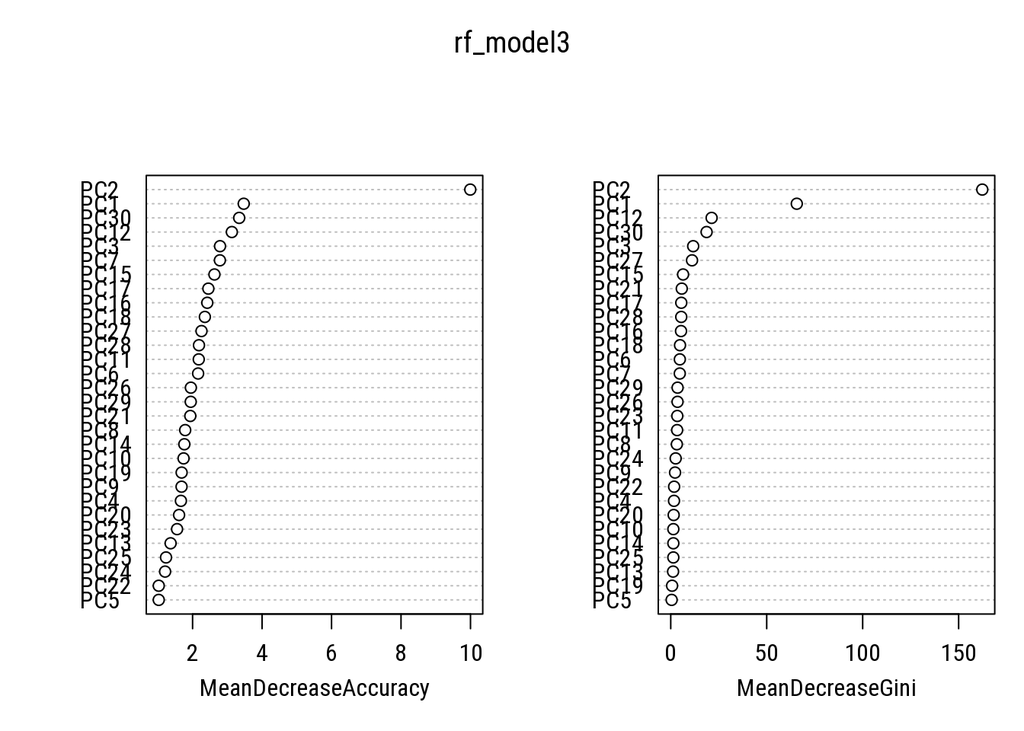

```r
varImpPlot(rf_model3)
```

Models are trained and hyper parametric tuning is carried out by adjusting the number of trees via the `ntree` option. I will move on to evaluate these models.

### 5.2. Evaluate Random forest models and get accuracy parameters.

```r
set.seed(786)
validation_set_scald$outcome<- as.factor(ifelse(validation_set_scald$outcome == 1, 1, 0))
sum(validation_set_scald$outcome == 0)
```

```
## [1] 82
```

```r
# Evaluate rf_model1
rf_pred1 <- predict(rf_model1, newdata=validation_set_scald, type="class")
# Get accuracy parameters rf_model1
confusionMatrix(data = rf_pred1, reference = validation_set_scald$outcome, positive = "1")
```

```
## Confusion Matrix and Statistics
##
##           Reference
## Prediction  0  1
##          0 29 11
##          1 53 64
##
##                Accuracy : 0.5924
##                  95% CI : (0.5112, 0.67)
##     No Information Rate : 0.5223
##     P-Value [Acc > NIR] : 0.04634
##
##                   Kappa : 0.2022
##
##  Mcnemar's Test P-Value : 2.975e-07
##
##             Sensitivity : 0.8533
##             Specificity : 0.3537
##          Pos Pred Value : 0.5470
##          Neg Pred Value : 0.7250
##              Prevalence : 0.4777
##          Detection Rate : 0.4076
##    Detection Prevalence : 0.7452
##       Balanced Accuracy : 0.6035
##
##        'Positive' Class : 1
##
```

```r
# Evaluate rf_model2
rf_pred2 <- predict(rf_model2, newdata=validation_set_scald, type="class")
# Get accuracy parameters rf_model2
confusionMatrix(data = rf_pred2, reference = validation_set_scald$outcome, positive = "1")
```

```
## Confusion Matrix and Statistics
##
##           Reference
## Prediction  0  1
##          0 53 13
##          1 29 62
##
##                Accuracy : 0.7325
##                  95% CI : (0.6561, 0.7999)
##     No Information Rate : 0.5223
##     P-Value [Acc > NIR] : 5.672e-08
##
##                   Kappa : 0.4687
##
##  Mcnemar's Test P-Value : 0.02064
##
##             Sensitivity : 0.8267
##             Specificity : 0.6463
##          Pos Pred Value : 0.6813
##          Neg Pred Value : 0.8030
##              Prevalence : 0.4777
##          Detection Rate : 0.3949
##    Detection Prevalence : 0.5796
##       Balanced Accuracy : 0.7365
##
##        'Positive' Class : 1
##
```

```r
# Evaluate rf_model3
rf_pred3 <- predict(rf_model3, newdata=validation_set_scald, type="class")
# Get accuracy parameters rf_model3
confusionMatrix(data = rf_pred3, reference = validation_set_scald$outcome, positive = "1")
```

```
## Confusion Matrix and Statistics
##
##           Reference
## Prediction  0  1
##          0 82 44
##          1  0 31
##
##                Accuracy : 0.7197
##                  95% CI : (0.6426, 0.7884)
##     No Information Rate : 0.5223
##     P-Value [Acc > NIR] : 3.428e-07
##
##                   Kappa : 0.4239
##
##  Mcnemar's Test P-Value : 9.022e-11
##
##             Sensitivity : 0.4133
##             Specificity : 1.0000
##          Pos Pred Value : 1.0000
##          Neg Pred Value : 0.6508
##              Prevalence : 0.4777
##          Detection Rate : 0.1975
##    Detection Prevalence : 0.1975
##       Balanced Accuracy : 0.7067
##
##        'Positive' Class : 1
##
```

```r
# Evaluate rf_model4
rf_pred4 <- predict(rf_model4, newdata=validation_set_scald, type="class")
# Get accuracy parameters rf_model4
confusionMatrix(data = rf_pred4, reference = validation_set_scald$outcome, positive = "1")
```

```
## Confusion Matrix and Statistics
##
##           Reference
## Prediction  0  1
##          0 58 34
##          1 24 41
##
##                Accuracy : 0.6306
##                  95% CI : (0.55, 0.7061)
##     No Information Rate : 0.5223
##     P-Value [Acc > NIR] : 0.0040
##
##                   Kappa : 0.2554
##
##  Mcnemar's Test P-Value : 0.2373
##
##             Sensitivity : 0.5467
##             Specificity : 0.7073
##          Pos Pred Value : 0.6308
##          Neg Pred Value : 0.6304
##              Prevalence : 0.4777
##          Detection Rate : 0.2611
##    Detection Prevalence : 0.4140
##       Balanced Accuracy : 0.6270
##
##        'Positive' Class : 1
##
```

```r
# Evaluate rf_model5
rf_pred5 <- predict(rf_model5, newdata=validation_set_scald, type="class")
# Get accuracy parameters rf_model5
confusionMatrix(data = rf_pred5, reference = validation_set_scald$outcome, positive = "1")
```

```
## Confusion Matrix and Statistics
##
##           Reference
## Prediction  0  1
##          0 17  4
##          1 65 71
##
##                Accuracy : 0.5605
##                  95% CI : (0.4792, 0.6395)
##     No Information Rate : 0.5223
##     P-Value [Acc > NIR] : 0.1899
##
##                   Kappa : 0.1488
##
##  Mcnemar's Test P-Value : 5.08e-13
##
##             Sensitivity : 0.9467
##             Specificity : 0.2073
##          Pos Pred Value : 0.5221
##          Neg Pred Value : 0.8095
##              Prevalence : 0.4777
##          Detection Rate : 0.4522
##    Detection Prevalence : 0.8662
##       Balanced Accuracy : 0.5770
##
##        'Positive' Class : 1
##
```

### 5.3. K-Fold cross validation for Random forest model.

```r
set.seed(786)
# Repeated cross validation
repeat_cv <- trainControl(method='repeatedcv', number=5, repeats=3)

# Train rf_model6
rf_model6 <- train(outcome~., data=traning_set_scald, method='rf', trControl=repeat_cv,
                   ntree = 10, importance = TRUE, proximity = TRUE,
                   type = "classification", metric='Accuracy')
rf_model6$finalModel
```

```
##
## Call:
##  randomForest(x = x, y = y, ntree = 10, mtry = param$mtry, importance = TRUE,      proximity = TRUE, type = "classification")
##                Type of random forest: classification
##                      Number of trees: 10
## No. of variables tried at each split: 16
##
##         OOB estimate of  error rate: 0.14%
## Confusion matrix:
##     0   1 class.error
## 0 378   0 0.000000000
## 1   1 346 0.002881844
```

```r
# Evaluate rf_model6
rf_pred6 <- predict(object=rf_model6, newdata=validation_set_scald)

# Accuracy
accuracy_rfmodel6 <- mean(rf_pred6 == validation_set_scald$outcome)*100
accuracy_rfmodel6
```

```
## [1] 70.06369
```

```r
#confusion matrix
confusionMatrix(data = rf_pred6, reference = validation_set_scald$outcome, positive = "1")
```

```
## Confusion Matrix and Statistics
##
##           Reference
## Prediction  0  1
##          0 76 41
##          1  6 34
##
##                Accuracy : 0.7006
##                  95% CI : (0.6225, 0.771)
##     No Information Rate : 0.5223
##     P-Value [Acc > NIR] : 4.056e-06
##
##                   Kappa : 0.3879
##
##  Mcnemar's Test P-Value : 7.071e-07
##
##             Sensitivity : 0.4533
##             Specificity : 0.9268
##          Pos Pred Value : 0.8500
##          Neg Pred Value : 0.6496
##              Prevalence : 0.4777
##          Detection Rate : 0.2166
##    Detection Prevalence : 0.2548
##       Balanced Accuracy : 0.6901
##
##        'Positive' Class : 1
##
```

```r
# Train rf_model7
rf_model7 <- train(outcome~., data=traning_set_scald, method='rf', trControl=repeat_cv,
                   ntree = 20, importance = TRUE, proximity = TRUE,
                   type = "classification", metric='Accuracy')
rf_model7$finalModel
```

```
##
## Call:
##  randomForest(x = x, y = y, ntree = 20, mtry = param$mtry, importance = TRUE,      proximity = TRUE, type = "classification")
##                Type of random forest: classification
##                      Number of trees: 20
## No. of variables tried at each split: 2
##
##         OOB estimate of  error rate: 0.14%
## Confusion matrix:
##     0   1 class.error
## 0 384   0 0.000000000
## 1   1 350 0.002849003
```

```r
# Evaluate rf_model7
rf_pred7 <- predict(object=rf_model7, newdata=validation_set_scald)

## Accuracy
accuracy_rfmodel7 <- mean(rf_pred7 == validation_set_scald$outcome)*100
accuracy_rfmodel7
```

```
## [1] 48.40764
```

We can compare both models with ROC.

```r
set.seed(786)
library(pROC)
# AUC rf_model3
rf_model3roc <- roc(as.numeric(rf_pred3), as.numeric(validation_set_scald$outcome))
rf_model3auc <- auc(rf_model3roc)
# AUC rf_model6
rf_model6roc <- roc(as.numeric(rf_pred6), as.numeric(validation_set_scald$outcome))
```

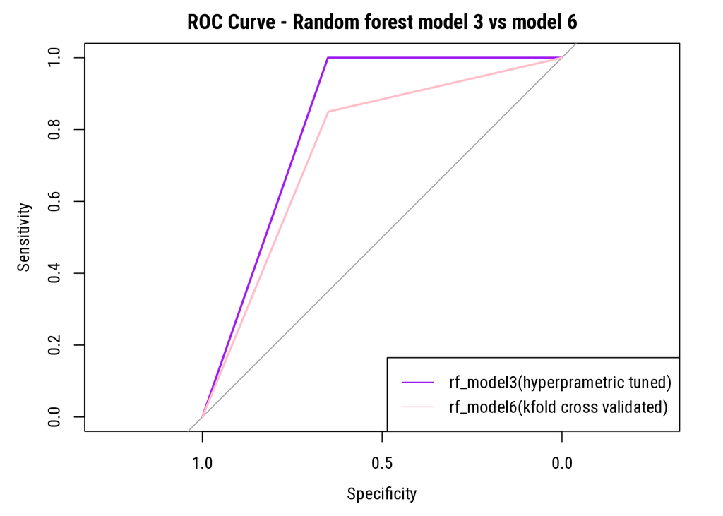

```r
rf_model6rocauc <- auc(rf_model6roc)

# Visualize ROC
plot(rf_model3roc, col = "purple", main = "ROC Curve - Random forest model 3 vs model 6")
lines(rf_model6roc, col = "pink")
legend("bottomright", legend = c("rf_model3(hyperprametric tuned)", "rf_model6(kfold cross validated)"), col = c("purple", "pink"), lty = 1)
```

### 5.5. Feature importance evaluation through Random forest modeling.

```r
set.seed(786)
# Get variable importance in a df
importance_rf_model6 <- importance(rf_model6$finalModel)
head(importance_rf_model6)
```

```
##             0         1 MeanDecreaseAccuracy MeanDecreaseGini
## PC1  1.500463  1.054093             1.492624       54.7646292
## PC2 35.891741 10.197408            21.176673      276.7484555
## PC3  1.054093  1.054093             1.054093        6.1634903
## PC4  0.000000  0.000000             0.000000        0.1947368
## PC5  0.000000  0.000000             0.000000        0.0000000
## PC6  1.499584  0.000000             1.512572        1.8625018
```

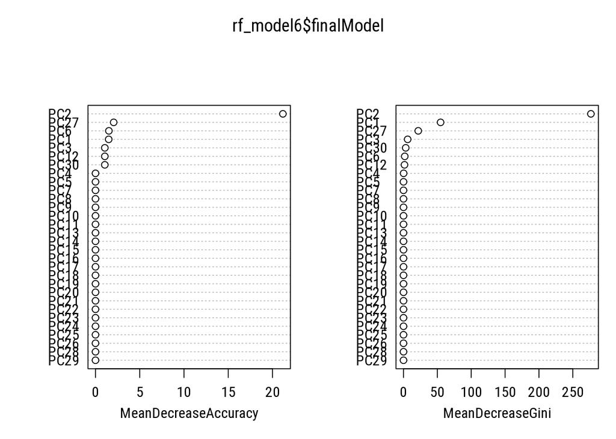

```r
varImpPlot(rf_model6$finalModel)
```

```r
important_vars <- varImp(rf_model6, scale=FALSE)
important_vars
```

```
## rf variable importance
##
##   only 20 most important variables shown (out of 30)
##
##      Importance
## PC2     23.0446
## PC1      1.2773
## PC3      1.0541
## PC27     1.0313
## PC6      0.7498
## PC12     0.5270
## PC30     0.5270
## PC19     0.0000
## PC17     0.0000
## PC13     0.0000
## PC23     0.0000
## PC16     0.0000
## PC5      0.0000
## PC18     0.0000
## PC11     0.0000
## PC24     0.0000
## PC8      0.0000
## PC15     0.0000
## PC22     0.0000
## PC26     0.0000
```

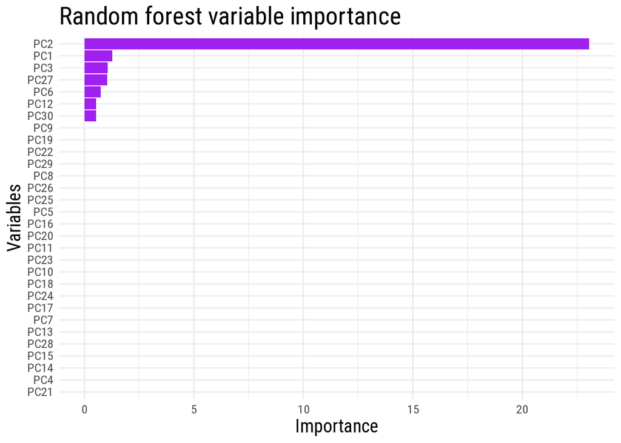

```r
# Visualize
important_vars %>%
  ggplot(aes(x=reorder(variables, importance), y=importance)) +
  geom_bar(stat='identity', fill= "purple") + coord_flip() + xlab('Variables') +
  labs(title='Random forest variable importance') + theme_minimal() +
  theme(axis.text = element_text(size = 10), axis.title = element_text(size = 15),
        plot.title = element_text(size = 20))
```

Here is a nice feature of Random forest, the most important features are PC2.

## 6. C5.0 model.

The C5.0 decision tree algorithm is robust and interpretable, handles both numerical and categorical data. it recursively partitions the feature space considering the most informative attributes and follows decision rules, increasing model interpretability. It is prone to overfitting if the trees are allowed to grow too deep. Pruning techniques and parameter tuning control overfitting and the built-in mechanisms like winnowing and boosting improve performance to reduce overfitting by iteratively making adjustements based on misclassified instances. for this analyis I will be using boosting methods. For all these reasons, I have added this to the initially proposed list of algos (Random forest, SVM, ANN).

```r
library(C50)
set.seed(786)
# Create the C5 model
c5model1 <- C5.0(outcome ~ ., data = traning_set_scald)
c5model1
```

```
##
## Call:
## C5.0.formula(formula = outcome ~ ., data = traning_set_scald)
##
## Classification Tree
## Number of samples: 735
## Number of predictors: 30
##
## Tree size: 2
##
## Non-standard options: attempt to group attributes
```

```r
summary(c5model1)
```

```
##
## Call:
## C5.0.formula(formula = outcome ~ ., data = traning_set_scald)
##
##
## C5.0 [Release 2.07 GPL Edition]      Mon Apr 15 10:44:36 2024
## -------------------------------
##
## Class specified by attribute `outcome'
##
## Read 735 cases (31 attributes) from undefined.data
##
## Decision tree:
##
## PC2 <= 0.6731152: 0 (385/1)
## PC2 > 0.6731152: 1 (350)
##
##
## Evaluation on training data (735 cases):
##
##      Decision Tree
##    ----------------
##    Size      Errors
##
##       2    1( 0.1%)   <<
##
##
##     (a)   (b)    <-classified as
##    ----  ----
##     384          (a): class 0
##       1   350    (b): class 1
##
##
##  Attribute usage:
##
##  100.00% PC2
##
##
## Time: 0.0 secs
```

```r
# Evaluate with validation data
pred_c5model1 <- predict(c5model1, validation_set_scald)

# Get accuracy parameters
confusionMatrix(data = pred_c5model1, reference = validation_set_scald$outcome, positive = "1")
```

```
## Confusion Matrix and Statistics
##
##           Reference
## Prediction  0  1
##          0 82 47
##          1  0 28
##
##                Accuracy : 0.7006
##                  95% CI : (0.6225, 0.771)
##     No Information Rate : 0.5223
##     P-Value [Acc > NIR] : 4.056e-06
##
##                   Kappa : 0.3836
##
##  Mcnemar's Test P-Value : 1.949e-11
##
##             Sensitivity : 0.3733
##             Specificity : 1.0000
##          Pos Pred Value : 1.0000
##          Neg Pred Value : 0.6357
##              Prevalence : 0.4777
##          Detection Rate : 0.1783
##    Detection Prevalence : 0.1783
##       Balanced Accuracy : 0.6867
##
##        'Positive' Class : 1
##
```

```r
# ROC C5 model
c5model1roc <- roc(as.numeric(pred_c5model1), as.numeric(validation_set_scald$outcome))
```

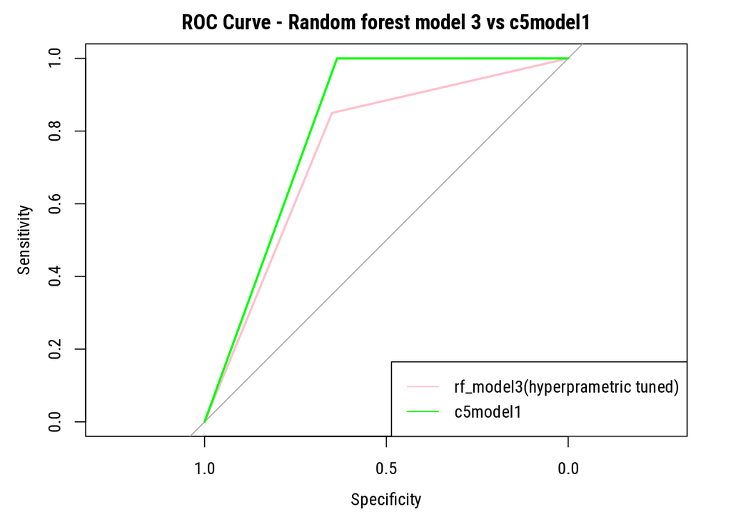

```r
c5model1auc <- auc(c5model1roc)

plot(rf_model6roc, col = "pink", main = "ROC Curve - Random forest model 3 vs c5model1")
lines(c5model1roc, col = "green")
legend("bottomright", legend = c("rf_model3(hyperprametric tuned)", "c5model1"), col = c("pink", "green"), lty = 1)
```

### 6.1. Boosting and Kfold cross validation for C5.0 model.

```r
# Cross validation
c50cv <- trainControl(method = "cv", number = 5)

#tuning params
C50_tune_grid <- expand.grid(.model = c("tree"), .trials = 1:10, .winnow = FALSE)

# Create a boosted C5.0 model
c5model_boost <- train(outcome ~ ., data = traning_set_scald, method = "C5.0", trControl = c50cv, tuneGrid = C50_tune_grid)
c5model_boost
```

```
## C5.0
##
## 735 samples
##  30 predictor
##   2 classes: '0', '1'
##
## No pre-processing
## Resampling: Cross-Validated (5 fold)
## Summary of sample sizes: 587, 588, 588, 588, 589
## Resampling results across tuning parameters:
##
##   trials  Accuracy   Kappa
##    1      0.9972881  0.9945653
##    2      0.9972881  0.9945653
##    3      0.9972881  0.9945653
##    4      0.9959276  0.9918398
##    5      0.9945762  0.9891311
##    6      0.9945762  0.9891311
##    7      0.9945762  0.9891311
##    8      0.9945762  0.9891311
##    9      0.9945762  0.9891311
##   10      0.9945762  0.9891311
##
## Tuning parameter 'model' was held constant at a value of tree
## Tuning
##  parameter 'winnow' was held constant at a value of FALSE
## Accuracy was used to select the optimal model using the largest value.
## The final values used for the model were trials = 1, model = tree and winnow
##  = FALSE.
```

```r
# evaluate boosted model
c5model_pred2 <- predict(c5model_boost, validation_set_scald)

# Confusion matrix
confusionMatrix(data = c5model_pred2, reference = validation_set_scald$outcome, positive = "1")
```

```
## Confusion Matrix and Statistics
##
##           Reference
## Prediction  0  1
##          0 82 47
##          1  0 28
##
##                Accuracy : 0.7006
##                  95% CI : (0.6225, 0.771)
##     No Information Rate : 0.5223
##     P-Value [Acc > NIR] : 4.056e-06
##
##                   Kappa : 0.3836
##
##  Mcnemar's Test P-Value : 1.949e-11
##
##             Sensitivity : 0.3733
##             Specificity : 1.0000
##          Pos Pred Value : 1.0000
##          Neg Pred Value : 0.6357
##              Prevalence : 0.4777
##          Detection Rate : 0.1783
##    Detection Prevalence : 0.1783
##       Balanced Accuracy : 0.6867
##
##        'Positive' Class : 1
##
```

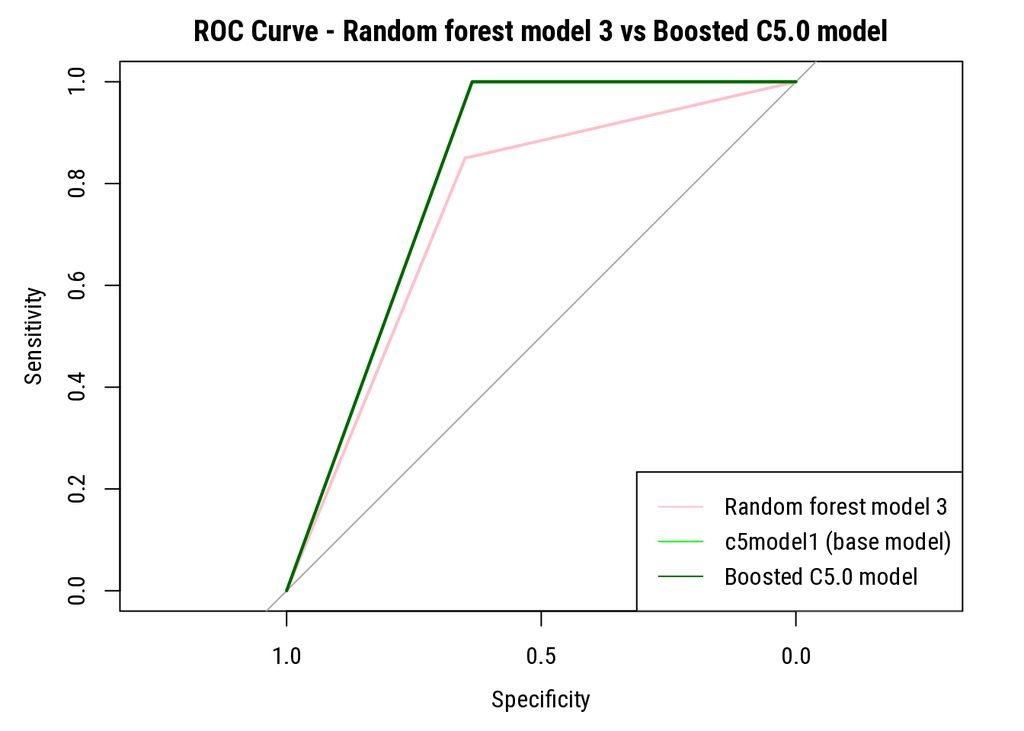

```r
# ROC C5 model
c5model_boost_roc <- roc(as.numeric(c5model_pred2), as.numeric(validation_set_scald$outcome))
c5model_boost_auc <- auc(c5model_boost_roc)

# Plot ROC curves
plot(rf_model6roc, col = "pink", main = "ROC Curve - Random forest model 3 vs Boosted C5.0 model")
lines(c5model1roc, col = "green")
lines(c5model_boost_roc, col = "darkgreen")
legend("bottomright", legend = c("Random forest model 3", "c5model1 (base model)",  "Boosted C5.0 model"), col = c("pink", "green", "darkgreen"), lty = 1)
```

Here the accuracy parameters remain the same for the base model and the boosted model. I will go with the base model.

## 7. SVM model.

Support Vector Machines are good for prediction tasks because they handle high-dimensional data, robust against overfitting and generalize unseen examples through kernel functions, and suitable for linear and non-linear classification problems. This model is less prone to overfitting with the regularization parameter ,C, handling overfitting and getting at a simpler decision boundary that generalizes unseen data. I proposed its use from the start and I have great expectations from this model as well as the previous two.

```r
set.seed(786)
# Fit SVM model
svm_model1 <- svm(outcome ~ ., data = traning_set_scald, kernel = "linear")
svm_model1
```

```
##
## Call:
## svm(formula = outcome ~ ., data = traning_set_scald, kernel = "linear")
##
##
## Parameters:
##    SVM-Type:  C-classification
##  SVM-Kernel:  linear
##        cost:  1
##
## Number of Support Vectors:  25
```

```r
# Model evaluation
svm_pred1 <- predict(svm_model1, newdata = validation_set_scald)

# Get confusion matrix
confusionMatrix(data = svm_pred1, reference = validation_set_scald$outcome,
                positive = "1")
```

```
## Confusion Matrix and Statistics
##
##           Reference
## Prediction  0  1
##          0 82 15
##          1  0 60
##
##                Accuracy : 0.9045
##                  95% CI : (0.8473, 0.9455)
##     No Information Rate : 0.5223
##     P-Value [Acc > NIR] : < 2.2e-16
##
##                   Kappa : 0.8069
##
##  Mcnemar's Test P-Value : 0.0003006
##
##             Sensitivity : 0.8000
##             Specificity : 1.0000
##          Pos Pred Value : 1.0000
##          Neg Pred Value : 0.8454
##              Prevalence : 0.4777
##          Detection Rate : 0.3822
##    Detection Prevalence : 0.3822
##       Balanced Accuracy : 0.9000
##
##        'Positive' Class : 1
##
```

```r
table(Actual = validation_set_scald$outcome,
                                     Predicted = svm_pred1)
```

```
##       Predicted
## Actual  0  1
##      0 82  0
##      1 15 60
```

### 7.1. SVM model improvement by regularization of C and use of k-fold crossvalidation.

```r
set.seed(786)
svm_grid1 <- expand.grid(C = 0.1)

# Perform cross-validated grid search with linear SVM
svm_tuned <- train(outcome ~ .,
                   data = traning_set_scald,
                   method = "svmLinear",
                   trControl = trainControl(method = "cv", number = 10),
                   tuneGrid = svm_grid1)

svm_grid2 <- expand.grid(C = c(0.1, 1, 10))
svm_tuned2 <- train(outcome ~ .,
                   data = traning_set_scald,
                   method = "svmLinear",
                   trControl = trainControl(method = "cv", number = 10),
                   tuneGrid = svm_grid2)


# Check the best model
svm_model2 <- svm_tuned$finalModel
svm_model2
```

```
## Support Vector Machine object of class "ksvm"
##
## SV type: C-svc  (classification)
##  parameter : cost C = 0.1
##
## Linear (vanilla) kernel function.
##
## Number of Support Vectors : 47
##
## Objective Function Value : -1.7899
## Training error : 0.001361
```

```r
svm_model3 <- svm_tuned2$finalModel
svm_model3
```

```
## Support Vector Machine object of class "ksvm"
##
## SV type: C-svc  (classification)
##  parameter : cost C = 1
##
## Linear (vanilla) kernel function.
##
## Number of Support Vectors : 25
##
## Objective Function Value : -2.8213
## Training error : 0
```

```r
# Evaluate improved model
svm_pred2 <- predict(svm_tuned, newdata = validation_set_scald)

#Get confusion matrix for improved model
confusionMatrix(data = svm_pred2, reference = validation_set_scald$outcome,
                positive = "1")
```

```
## Confusion Matrix and Statistics
##
##           Reference
## Prediction  0  1
##          0 82 13
##          1  0 62
##
##                Accuracy : 0.9172
##                  95% CI : (0.8626, 0.9552)
##     No Information Rate : 0.5223
##     P-Value [Acc > NIR] : < 2.2e-16
##
##                   Kappa : 0.8328
##
##  Mcnemar's Test P-Value : 0.0008741
##
##             Sensitivity : 0.8267
##             Specificity : 1.0000
##          Pos Pred Value : 1.0000
##          Neg Pred Value : 0.8632
##              Prevalence : 0.4777
##          Detection Rate : 0.3949
##    Detection Prevalence : 0.3949
##       Balanced Accuracy : 0.9133
##
##        'Positive' Class : 1
##
```

```r
# Try radial kernel
library(ROCR)
library(kernlab)
# Cross validation
set.seed(786)
ctrl_radial <- trainControl(method="cv",
                     number = 2,
                     summaryFunction=twoClassSummary,
                     classProbs=TRUE)

#  Fine tune with grid search
grid_radial <- expand.grid(sigma = c(.01, .015, 0.2), C = c(0.75, 0.9, 1, 1.1, 1.25))

training_set_features <- traning_set_scald[,-1]
training_set_outcome <- traning_set_scald[,1]
str(training_set_outcome)
```

```
##  Factor w/ 2 levels "0","1": 1 1 1 1 1 1 1 1 1 1 ...
```

```r
levels(training_set_outcome)  <- c("normal", "tumor")
#Train SVM
svm_tune_radial <- train(x=training_set_features, y= training_set_outcome,
                  method = "svmRadial", metric="ROC", tuneGrid = grid_radial,
                  trControl=ctrl_radial)

svm_tune_radial
```

```
## Support Vector Machines with Radial Basis Function Kernel
##
## 735 samples
##  30 predictor
##   2 classes: 'normal', 'tumor'
##
## No pre-processing
## Resampling: Cross-Validated (2 fold)
## Summary of sample sizes: 368, 367
## Resampling results across tuning parameters:
##
##   sigma  C     ROC  Sens  Spec
##   0.010  0.75  1    1     0.9943182
##   0.010  0.90  1    1     0.9943182
##   0.010  1.00  1    1     0.9943182
##   0.010  1.10  1    1     0.9943182
##   0.010  1.25  1    1     0.9943182
##   0.015  0.75  1    1     0.9943182
##   0.015  0.90  1    1     0.9914773
##   0.015  1.00  1    1     0.9943182
##   0.015  1.10  1    1     0.9943182
##   0.015  1.25  1    1     0.9943182
##   0.200  0.75  1    1     1.0000000
##   0.200  0.90  1    1     1.0000000
##   0.200  1.00  1    1     1.0000000
##   0.200  1.10  1    1     1.0000000
##   0.200  1.25  1    1     1.0000000
##
## ROC was used to select the optimal model using the largest value.
## The final values used for the model were sigma = 0.2 and C = 0.75.
```

```r
# Predict Target Label
validation_features <-validation_set_scald[,-1]
validation_outcomes <- validation_set_scald[, 1]
str(validation_outcomes)
```

```
##  Factor w/ 2 levels "0","1": 1 1 1 1 1 1 1 1 1 1 ...
```

```r
levels(validation_outcomes) <- c("normal", "tumor")
svm_pred3 <- predict(svm_tune_radial, validation_features, type="prob")[2]
head(svm_pred3)
```

```
##       tumor
## 1 0.9961554
## 2 0.9961554
## 3 0.9961554
## 4 0.9961554
## 5 0.9961554
## 6 0.9961554
```

```r
# Model Performance Statistics
svm_radial_pred_val <-prediction(svm_pred3[,1], validation_outcomes)

# Get AUC
performance_val <- performance(svm_radial_pred_val,"auc")
performance_val
```

```
## A performance instance
##   'Area under the ROC curve'
```

```r
# Get tpr and fpr
performance_val <- performance(svm_radial_pred_val, "tpr", "fpr")
performance_val
```

```
## A performance instance
##   'False positive rate' vs. 'True positive rate' (alpha: 'Cutoff')
##   with 2 data points
```

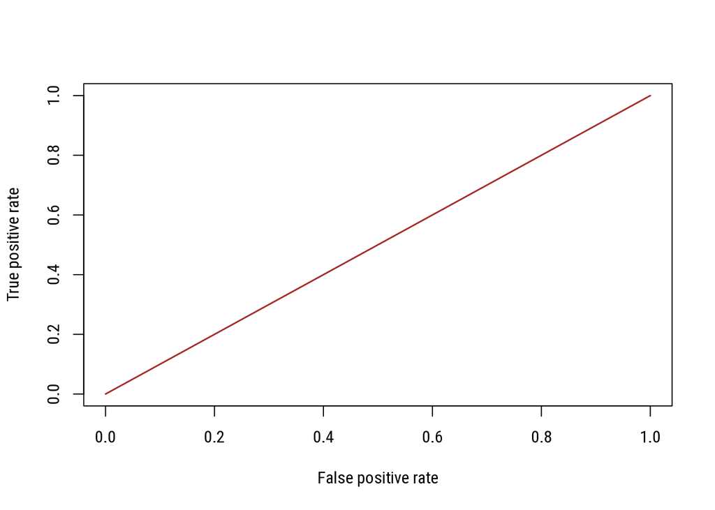

```r
# Plot ROC
plot(performance_val, col = "brown", lwd = 1.5)
```

I tried to tune the model to a nonlinear radial kernel with a range of cost and gamma values, but did not get a proper ROC curve and thus I will take the linear svm tuned model as the best among the three svm models.

## 8. ANN model.

I will leverage the perculiarities of ANN hidden layers, ability to cope with multi-dimensionality and capability to pick up patterns to model upon to predict the outcome. To handle overfitting, the ANN model can leverage on L1 and L2 regularization, cross fold validation or drop out techniques. I will use k-fold cross validation to combat overfitting.

```r
library(DescTools)
library(NeuralNetTools)
set.seed(786)
# fit annmodel
annmodel <- train(form = outcome ~.,data = traning_set_scald,
                  method = "nnet",trace = FALSE)
annmodel
```

```
## Neural Network
##
## 735 samples
##  30 predictor
##   2 classes: '0', '1'
##
## No pre-processing
## Resampling: Bootstrapped (25 reps)
## Summary of sample sizes: 735, 735, 735, 735, 735, 735, ...
## Resampling results across tuning parameters:
##
##   size  decay  Accuracy   Kappa
##   1     0e+00  0.9513902  0.8979864
##   1     1e-04  0.9555207  0.9106846
##   1     1e-01  0.9955114  0.9909938
##   3     0e+00  0.9938784  0.9877150
##   3     1e-04  0.9926695  0.9853056
##   3     1e-01  0.9955114  0.9909938
##   5     0e+00  0.9920020  0.9839422
##   5     1e-04  0.9952648  0.9904966
##   5     1e-01  0.9955114  0.9909938
##
## Accuracy was used to select the optimal model using the largest value.
## The final values used for the model were size = 1 and decay = 0.1.
```

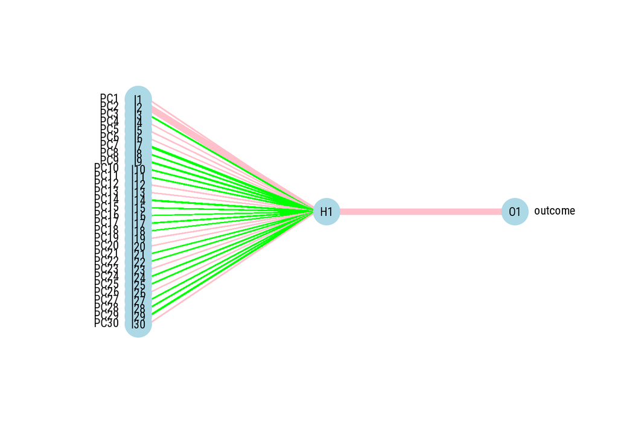

```r
plotnet(annmodel, pos_col = "pink", neg_col = "green", bias = FALSE,
        circle_cex = 4, cex_val = 0.8)
```

```r
# Evaluate annmodel
annmodel_pred <- predict(object = annmodel,newdata = validation_set_scald)
# Confusion matrix annmodel
confusionMatrix(data = annmodel_pred,
                reference = validation_set_scald$outcome,positive = "1")
```

```
## Confusion Matrix and Statistics
##
##           Reference
## Prediction  0  1
##          0 82 72
##          1  0  3
##
##                Accuracy : 0.5414
##                  95% CI : (0.4601, 0.6211)
##     No Information Rate : 0.5223
##     P-Value [Acc > NIR] : 0.3452
##
##                   Kappa : 0.0417
##
##  Mcnemar's Test P-Value : <2e-16
##
##             Sensitivity : 0.04000
##             Specificity : 1.00000
##          Pos Pred Value : 1.00000
##          Neg Pred Value : 0.53247
##              Prevalence : 0.47771
##          Detection Rate : 0.01911
##    Detection Prevalence : 0.01911
##       Balanced Accuracy : 0.52000
##
##        'Positive' Class : 1
##
```

### 8.1. Model Improvement by hyperparametric tuning decay and size plus kfold cross validation.

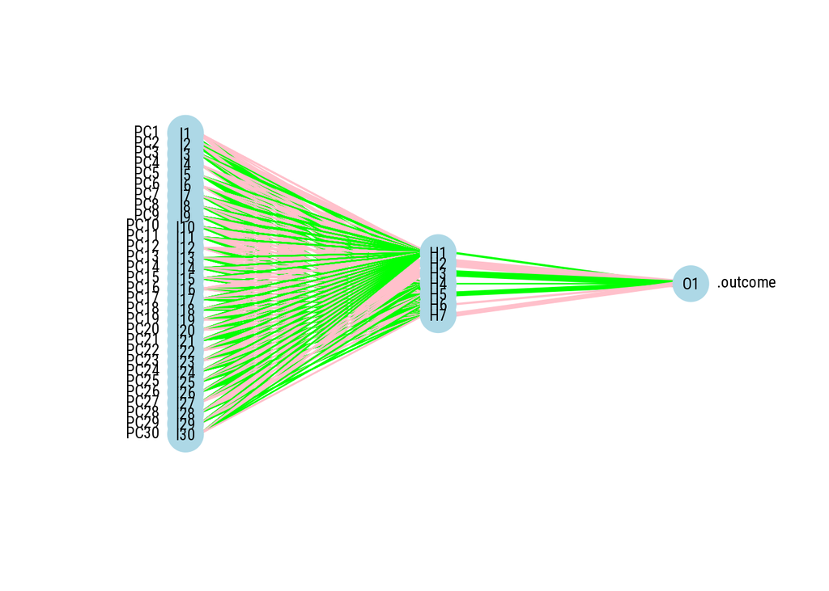

```r
set.seed(786)
# cross validation params
ann_ctrl <- trainControl(method = "repeatedcv", number = 5, repeats = 3, search = "grid")

# grid tuning ranges
ann_grid <- expand.grid(size = seq(from = 1, to = 7, by = 2),
                      decay = seq(from = 0, to = 0.1, by = 0.01))

# Fit tuned ann model
set.seed(786)
ann_model_tuned <- train(form = outcome ~., data = traning_set_scald,
                         method = "nnet", trControl = ann_ctrl,
                         tuneGrid = ann_grid, trace = FALSE)

#Visualize model
plotnet(mod_in = ann_model_tuned$finalModel, pos_col = "pink", neg_col = "green",
        bias = FALSE, circle_cex = 4, cex_val = 0.8)
```

```r
# Evaluate ann_model_tuned
annmodel_pred <- predict(object = ann_model_tuned,newdata = validation_set_scald)
# Confusion matrix ann_model_tuned
confusionMatrix(data = ann_model_tuned,
                reference = validation_set_scald$outcome,positive = "1")
```

```
## Cross-Validated (5 fold, repeated 3 times) Confusion Matrix
##
## (entries are percentual average cell counts across resamples)
##
##           Reference
## Prediction    0    1
##          0 52.2  0.3
##          1  0.0 47.5
##
##  Accuracy (average) : 0.9973
```

The model has been tuned through ranges of values for decay and size. A 5-fold cross validation has been done with 3 repeats. These led to an accuracy of 99.73%. The confusion matrix did not show other accuracy parameters. I am unable to get the ROC curves for the ann models so I will compare them with other models based on F1 statistic and recall.

## 9. Model comparison.

### 9.1. Individual model comparison.

Here I will use basic accuracy parameters to get the Recall and F1 scores and compare models based on these. ROC comparisons have already been made above.

Accuracy= TP+TN/(TP+TN+FP+FN)

Precision/Positive Predictive Value = TP/(TP+FP)

Recall/Sensitivity/True Positive Rate = TP/(TP+FN)

Specificity/True Negative Rate = TN/(TN+FP)

False Positive Rate/Fall-Out/False positive rate = 1- specificity OR FP/(TN + FP)

F1 Score = 2((precision * Recall)/(Precion + Recall))

NB: TP=True Positives TN=True Negatives FP=False Positives FN=False Negatives

Based on these, I derived the data below for each model:

[output not shown]

[output not shown]

From the above the SVM and ann models outperform the tree models, although I could not obtain the AUC and ROC for these to compare further. I would pick the SVM model as the best because I consider the ann model may be on the overfitted end (considering the broad difference between accuracy parameters of the untuned and tuned models).